1. **Housing prices.** @Brown2004 describe “A Hierarchical Linear Model Approach for Assessing the Effects of House and Neighborhood Characteristics on Housing Prices”. Based on the title of their paper: (a) give the observational units at Level One and Level Two, and (b) list potential explanatory variables at both Level One and Level Two.
1. Observational Units:
- Level One: Individual houses or properties
- Level Two: Neighborhoods or groups of houses
2. Potential Explanatory Variables:
- Level One (Individual House):
  - House size
  - Number of bedrooms and bathrooms
  - Age of the house
  - Condition of the house
- Level Two (Neighborhood):
  - Median income of the neighborhood
  - Crime rates in the neighborhood
  - Quality of schools in the neighborhood
  - Neighborhood aesthetics and overall environment
3. In the preceding problem, for each of the following sets of predictors: (a) write out the two-level model for predicting housing prices, (b) write out the corresponding composite model, and (c) determine how many model parameters (fixed effects and variance components) must be estimated.
   - Square footage, number of bedrooms
   - Median neighborhood income, rating of neighborhood schools
   - Square footage, number of bedrooms, age of house, median neighborhood housing price
   - Square footage, median neighborhood income, rating of neighborhood schools, median neighborhood housing price
4. **Square Footage, Number of Bedrooms:**
   - Two-Level Model:
     $$\text{Level 1: } \text{Housing Price}_{ij} = \beta_{0j} +
     \beta_{1j}(\text{Square Footage}_{ij}) + \beta_{2j}(\text{Number of
     Bedrooms}_{ij}) + e_{ij}$$
     $$\text{Level 2: } \beta_{0j} = \gamma_{00} + u_{0j} \quad \text{and}
     \quad \beta_{1j} = \gamma_{10} + u_{1j} \quad \text{and} \quad
     \beta_{2j} = \gamma_{20} + u_{2j}$$
   - Composite Model:
     $$\text{Housing Price}_{ij} = \gamma_{00} + \gamma_{10}(\text{Square
     Footage}_{ij}) + \gamma_{20}(\text{Number of Bedrooms}_{ij}) + u_{0j} +
     u_{1j}(\text{Square Footage}_{ij}) + u_{2j}(\text{Number of
     Bedrooms}_{ij}) + e_{ij}$$
   - Number of Parameters:
     - Fixed Effects: 3 ($\gamma_{00}, \gamma_{10}, \gamma_{20}$)
     - Variance Components: 3 ($u_{0j}, u_{1j}, u_{2j}$)
5. **Median Neighborhood Income, Rating of Neighborhood Schools:**
   - Two-Level Model:
     $$\text{Level 1: } \text{Housing Price}_{ij} = \beta_{0j} +
     \beta_{1j}(\text{Median Income}_{j}) + \beta_{2j}(\text{School
     Rating}_{j}) + e_{ij}$$
     $$\text{Level 2: } \beta_{0j} = \gamma_{00} + u_{0j} \quad \text{and}
     \quad \beta_{1j} = \gamma_{10} + u_{1j} \quad \text{and} \quad
     \beta_{2j} = \gamma_{20} + u_{2j}$$
   - Composite Model:
     $$\text{Housing Price}_{ij} = \gamma_{00} + \gamma_{10}(\text{Median
     Income}_{j}) + \gamma_{20}(\text{School Rating}_{j}) + u_{0j} +
     u_{1j}(\text{Median Income}_{j}) + u_{2j}(\text{School Rating}_{j}) +
     e_{ij}$$
   - Number of Parameters:
     - Fixed Effects: 3 ($\gamma_{00}, \gamma_{10}, \gamma_{20}$)
     - Variance Components: 3 ($u_{0j}, u_{1j}, u_{2j}$)
6. **Square Footage, Number of Bedrooms, Age of House, Median Neighborhood Housing Price:**
   - Two-Level Model:
     $$\text{Level 1: } \text{Housing Price}_{ij} = \beta_{0j} +
     \beta_{1j}(\text{Square Footage}_{ij}) + \beta_{2j}(\text{Number of
     Bedrooms}_{ij}) + \beta_{3j}(\text{Age of House}_{ij}) +
     \beta_{4j}(\text{Median Housing Price}_{j}) + e_{ij}$$
     $$\text{Level 2: } \beta_{0j} = \gamma_{00} + u_{0j} \quad \text{and so
     on...}$$
   - Composite Model:
     $$\text{Housing Price}_{ij} = \gamma_{00} + \gamma_{10}(\text{Square
     Footage}_{ij}) + \gamma_{20}(\text{Number of Bedrooms}_{ij}) +
     \gamma_{30}(\text{Age of House}_{ij}) + \gamma_{40}(\text{Median Housing
     Price}_{j}) + \text{random effects terms} + e_{ij}$$
   - Number of Parameters:
     - Fixed Effects: 5 ($\gamma_{00}, \gamma_{10}, \gamma_{20}, \gamma_{30}, \gamma_{40}$)
7. **Square Footage, Median Neighborhood Income, Rating of Neighborhood Schools, Median Neighborhood Housing Price:**

**Square Footage, Median Neighborhood Income, Rating of Neighborhood Schools, Median Neighborhood Housing Price:**

- **Two-Level Model:**
  $$\begin{align*}
  \text{Level 1: } & \text{Housing Price}_{ij} = \beta_{0j} +
  \beta_{1j}(\text{Square Footage}_{ij}) + \beta_{2j}(\text{Median
  Income}_{j}) + \beta_{3j}(\text{School Rating}_{j}) +
  \beta_{4j}(\text{Median Housing Price}_{j}) + e_{ij} \\
  \text{Level 2: } & \beta_{0j} = \gamma_{00} + u_{0j} \quad \text{and
  so on...}
  \end{align*}$$
- **Composite Model:**
  $$\text{Housing Price}_{ij} = \gamma_{00} + \gamma_{10}(\text{Square
  Footage}_{ij}) + \gamma_{20}(\text{Median Income}_{j}) +
  \gamma_{30}(\text{School Rating}_{j}) + \gamma_{40}(\text{Median Housing
  Price}_{j}) + \text{random effects terms} + e_{ij}$$
- **Number of Parameters:**
  - Fixed Effects: 5 ($\gamma_{00}, \gamma_{10}, \gamma_{20}, \gamma_{30}, \gamma_{40}$)
6. Why is the contour plot for multivariate normal density in Figure @ref(fig:contour-boundary)(b) tilted from southwest to northeast, but the contour plot in Figure @ref(fig:contour-boundary)(a) is not tilted?

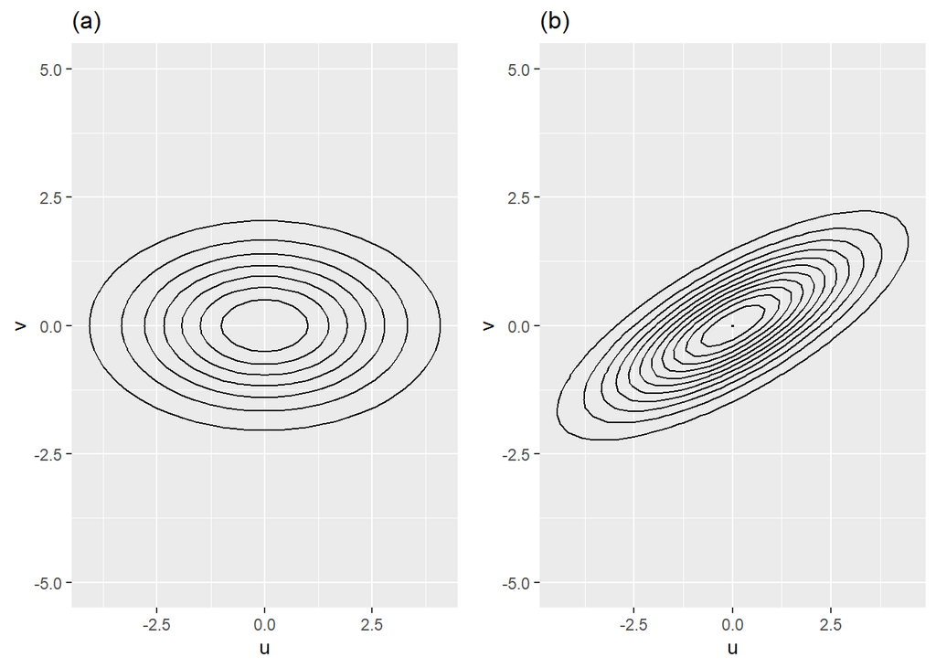

Contour plots illustrating a multivariate normal density with (a) no correlation between error terms, and (b) positive correlation between error terms.

10. Give a short rule in your own words describing when an interpretation of an estimated coefficient should “hold constant” another covariate or “set to 0” that covariate (see Section @ref(interp:modeld)).

When interpreting an estimated coefficient, you should hold constant another covariate when you want to isolate the effect of the variable of interest while keeping the other covariate constant at a specific value. On the other hand, you should set to 0 a covariate when it is a categorical variable, and you want to compare the group represented by 0 to the reference group, understanding the change in the dependent variable when that specific covariate is absent.

14. Interpret other estimated parameters from Model F beyond those interpreted in Section @ref(modelf): $\hat{\alpha}_{0}$, $\hat{\alpha}_{2}$, $\hat{\alpha}_{3}$, $\hat{\beta}_{0}$, $\hat{\gamma}_{0}$, $\hat{\zeta}_{0}$, $\hat{\rho}_{wx}$, $\hat{\sigma}^{2}$, $\hat{\sigma}_{u}^{2}$, and $\hat{\sigma}_{z}^{2}$.

$mpqab = 0.20$ (mpqab): A one-unit increase in the absorption subscale score is associated with an estimated 0.20 mean increase in performance anxiety for musicians, after controlling for previous diary entries, audience, positive emotionality, absorption, and instrument.

$students= 3.61$ (students): When the audience consists of students compared to instructors, there is an estimated 3.61 mean increase in performance anxiety for musicians performing in an ensemble group (solo=0), controlling for the effects of previous diary entries, audience, positive emotionality, absorption, and instrument.

## Guided

Music performance joy. In this chapter, we studied models for predicting music performance anxiety, as measured by the negative affect scale from the PANAS instrument. Now we will examine models for predicting the happiness of musicians prior to performances, as measured by the positive affect scale from the PANAS instrument.

To begin, run the following models:

Model A = unconditional means model Model B = indicator for instructor audience type and indicator for student audience type at Level One; no Level Two predictors Model C = indicator for instructor audience type and indicator for student audience type at Level One; centered MPQ absorption subscale as Level Two predictor for intercept and all slope terms Model D = indicator for instructor audience type and indicator for student audience type at Level One; centered MPQ absorption subscale and a male indicator as Level Two predictors for intercept and all slope terms

```r
music = read.csv("data/musicdata.csv")
head(music)
```

```
##   X id diary previous   perform_type      memory           audience pa na age
## 1 1  1     1        0           Solo Unspecified         Instructor 40 11  18
## 2 2  1     2        1 Large Ensemble      Memory Public Performance 33 19  18
## 3 3  1     3        2 Large Ensemble      Memory Public Performance 49 14  18
## 4 4  1     4        3           Solo      Memory Public Performance 41 19  18
## 5 5  1     5        4           Solo      Memory         Student(s) 31 10  18
## 6 6  1     6        5           Solo      Memory         Student(s) 33 13  18
##   gender instrument years_study mpqab mpqsr mpqpem mpqnem mpqcon
## 1 Female      voice           3    16     7     52     16     30
## 2 Female      voice           3    16     7     52     16     30
## 3 Female      voice           3    16     7     52     16     30
## 4 Female      voice           3    16     7     52     16     30
## 5 Female      voice           3    16     7     52     16     30
## 6 Female      voice           3    16     7     52     16     30
```

- `id` = unique musician identification number
- `diary` = cumulative total of diaries filled out by musician
- `perf_type` = type of performance (Solo, Large Ensemble, or Small Ensemble)
- `audience` = who attended (Instructor, Public, Students, or Juried)
- `memory` = performed from Memory, using Score, or Unspecified
- `na` = negative affect score from PANAS
- `gender` = musician gender
- `instrument` = Voice, Orchestral, or Piano
- `mpqab` = absorption subscale from MPQ
- `mpqpem` = positive emotionality (PEM) composite scale from MPQ
- `mpqnem` = negative emotionality (NEM) composite scale from MPQ

```r
model_A <- lmer(pa~ 1 + (1|id), REML=T, data=music)

music <- music %>%
  mutate(students = ifelse(audience=="Student(s)",1,0),
         juried = ifelse(audience=="Juried Recital",1,0),
         public = ifelse(audience=="Public Performance",1,0),
         instructor = ifelse(audience=="Instructor",1,0),
         cmpqab = mpqab - mean(mpqab),
         female = ifelse(gender=="Female",1,0),
         male = ifelse(gender=="Male", 1, 0)
)

model_B <- lmer(pa ~ instructor + students + (instructor +
students|id), REML=T, data=music)
```

```
## boundary (singular) fit: see help('isSingular')
```

```r
model_C <- lmer(pa ~ instructor + students + cmpqab +
cmpqab:students + cmpqab:instructor +
(instructor + students|id), REML=T, data=music)


model_D <- lmer(pa ~ instructor + students + cmpqab + male +
cmpqab:students + cmpqab:instructor + male:students +
male:instructor + (instructor + students|id), REML=T,
data=music)
```

```
## boundary (singular) fit: see help('isSingular')
```

```
a. Perform an exploratory data analysis by comparing positive affect (happiness) to Level One and Level Two covariates using appropriate graphs. Comment on interesting trends, supporting your comments with appropriate summary statistics.
```

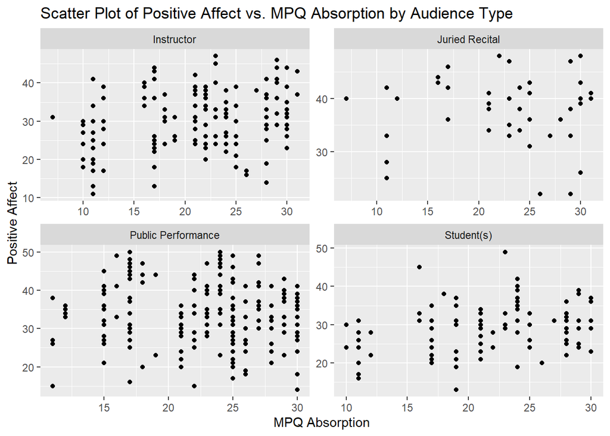

```r
ggplot(music, aes(x = mpqab, y = pa)) +
  geom_point() +
  facet_wrap(~audience, scales = "free") +
  labs(title = "Scatter Plot of Positive Affect vs. MPQ Absorption by Audience Type",
       x = "MPQ Absorption", y = "Positive Affect")
```

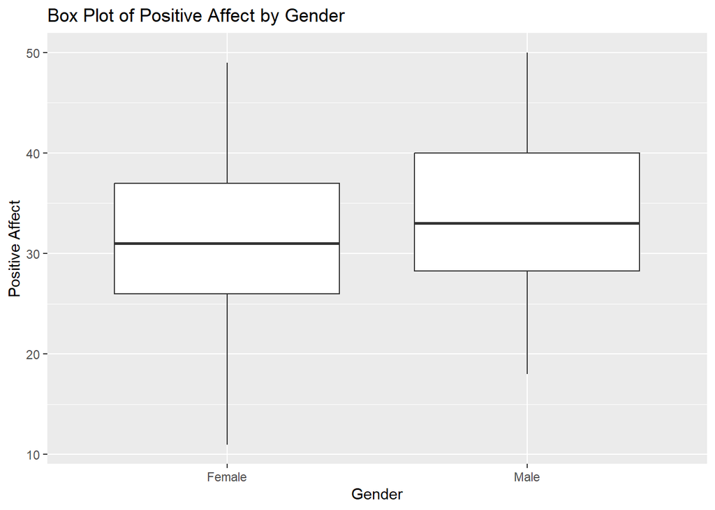

```r
ggplot(music, aes(x = gender, y = pa)) +
  geom_boxplot() +
  labs(title = "Box Plot of Positive Affect by Gender",
       x = "Gender", y = "Positive Affect")
```

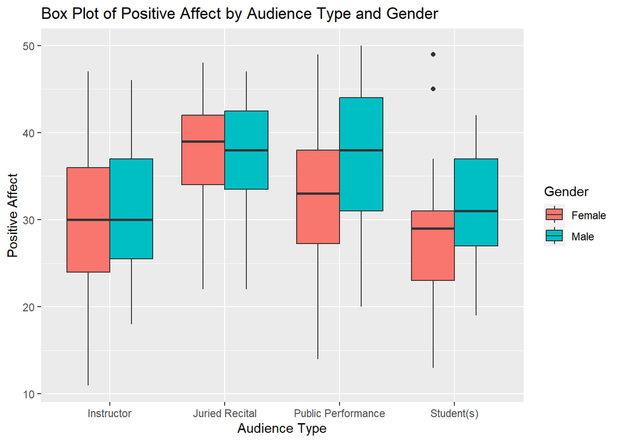

```r
ggplot(music, aes(x = audience, y = pa, fill = gender)) +
  geom_boxplot(position = "dodge") +
  labs(title = "Box Plot of Positive Affect by Audience Type and Gender",
       x = "Audience Type", y = "Positive Affect", fill = "Gender")
```

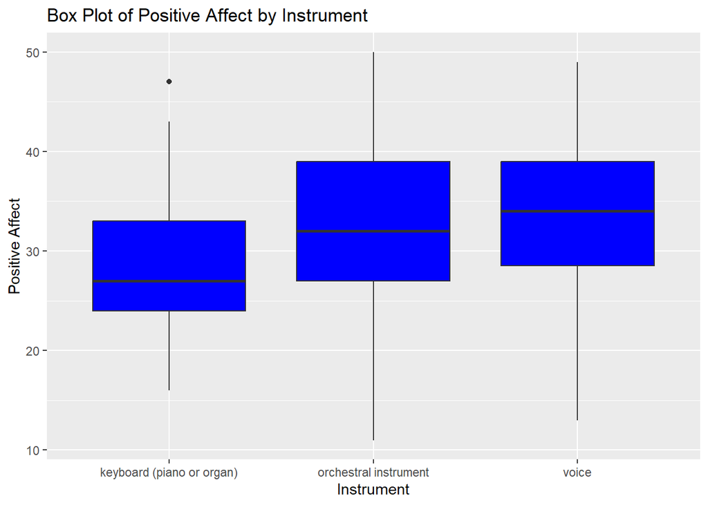

```r
ggplot(music, aes(x = instrument, y = pa)) +
  geom_boxplot(fill = "blue", position = "dodge") +
  labs(title = "Box Plot of Positive Affect by Instrument",
       x = "Instrument", y = "Positive Affect")
```

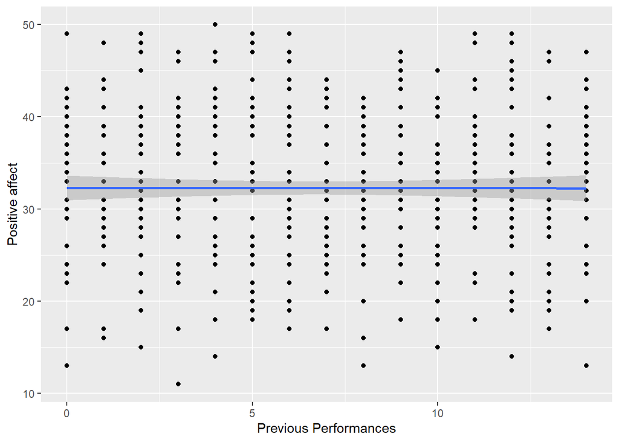

```r
ggplot(data=music, aes(x=previous,y=pa)) +
geom_point() +
geom_smooth(method="lm") +
ylab("Positive affect") + xlab("Previous Performances")
```

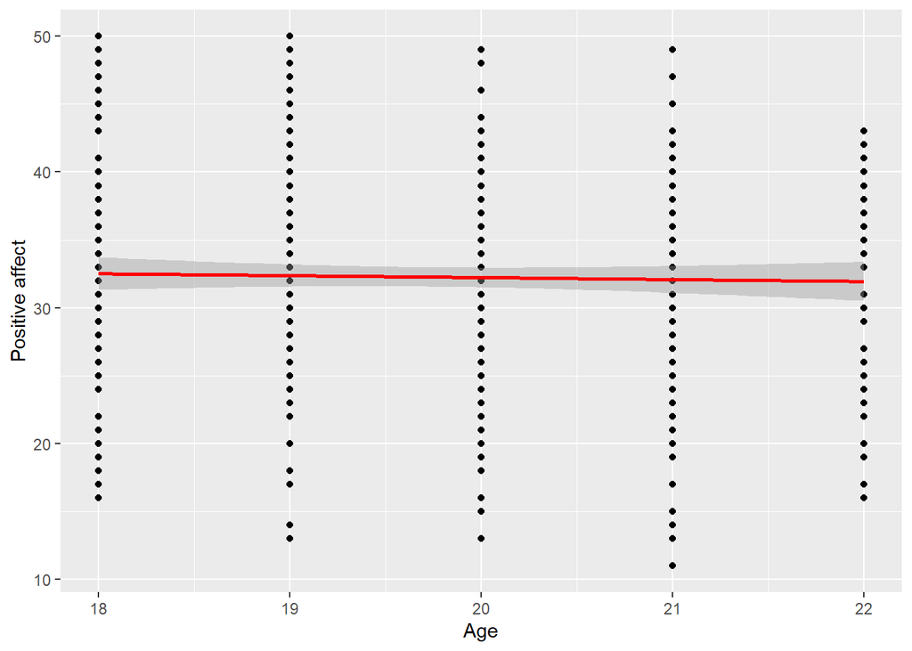

```r
generate_scatter_plot <- function(data, x_var, y_var, x_label, y_label) {
  ggplot(data = data, aes(x = !!rlang::sym(x_var), y = !!rlang::sym(y_var))) +
    geom_point() +
    geom_smooth(method = "lm", color = "red") +
    ylab(y_label) +
    xlab(x_label)
}


generate_scatter_plot(music, "age", "pa", "Age", "Positive affect")
```

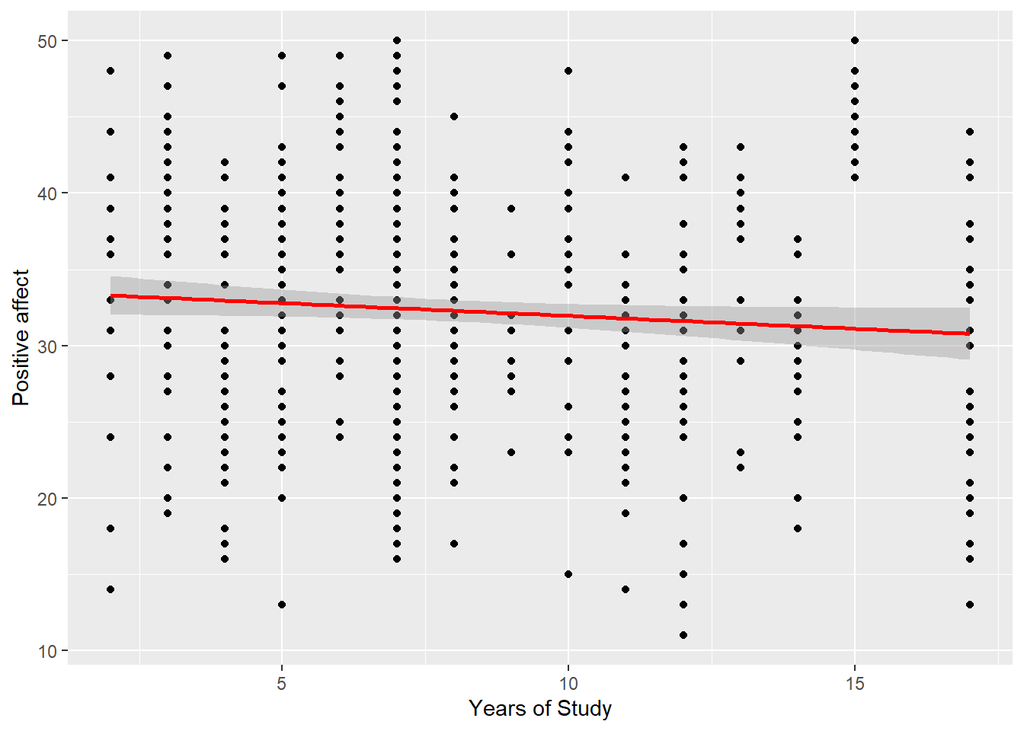

```r
generate_scatter_plot(music, "years_study", "pa", "Years of Study", "Positive affect")
```

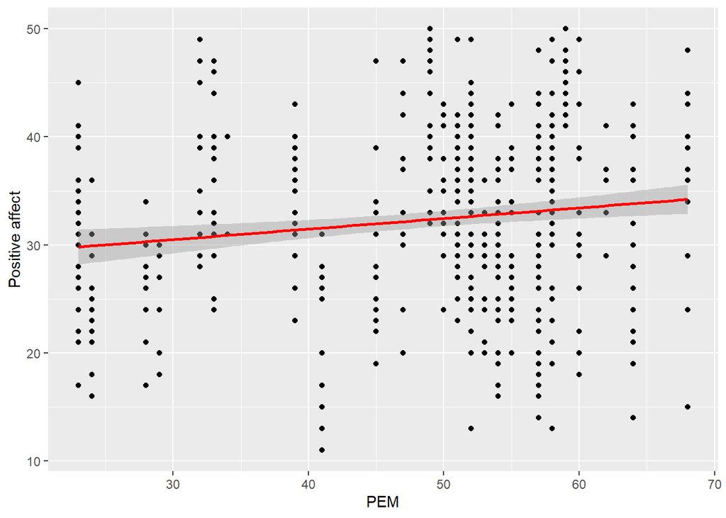

```r
generate_scatter_plot(music, "mpqpem", "pa", "PEM", "Positive affect")
```

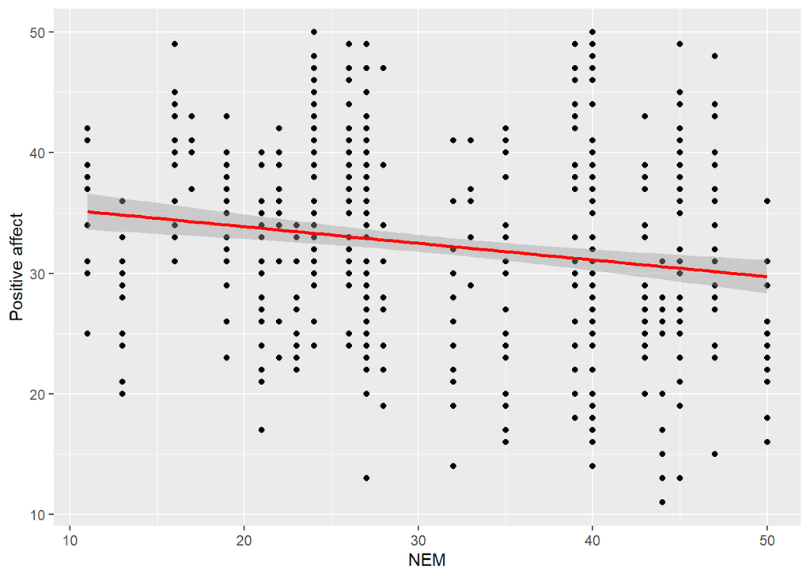

```r
generate_scatter_plot(music, "mpqnem", "pa", "NEM", "Positive affect")
```

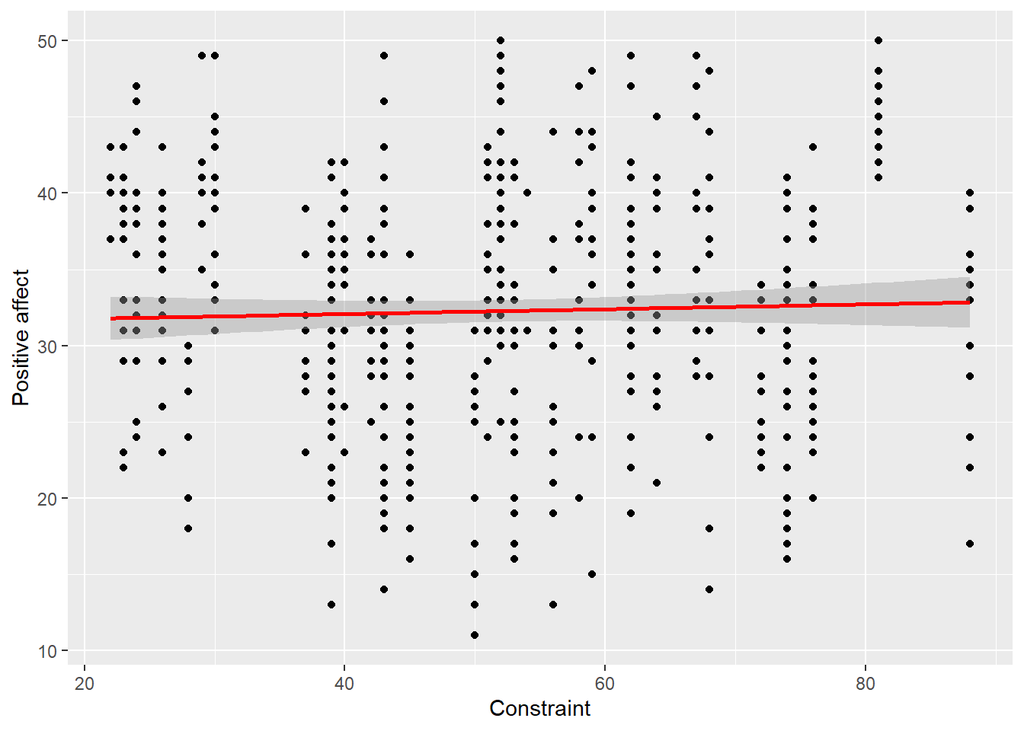

```r
generate_scatter_plot(music, "mpqcon", "pa", "Constraint", "Positive affect")
```

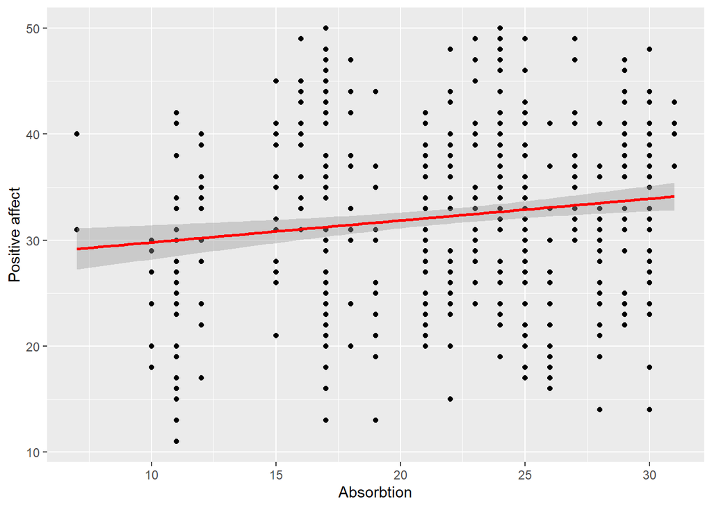

```r
generate_scatter_plot(music, "mpqab", "pa", "Absorbtion", "Positive affect")
```

```r
by(music$pa,music$memory,summary)
```

```
## music$memory: Memory
##    Min. 1st Qu.  Median    Mean 3rd Qu.    Max.
##   18.00   30.00   34.00   34.21   39.00   49.00
## ------------------------------------------------------------
## music$memory: Score
##    Min. 1st Qu.  Median    Mean 3rd Qu.    Max.
##   11.00   25.00   31.00   31.13   37.00   50.00
## ------------------------------------------------------------
## music$memory: Unspecified
##    Min. 1st Qu.  Median    Mean 3rd Qu.    Max.
##   13.00   26.00   31.00   32.62   40.00   50.00
```

```r
by(music$pa,music$perform_type,summary)
```

```
## music$perform_type: Large Ensemble
##    Min. 1st Qu.  Median    Mean 3rd Qu.    Max.
##   14.00   30.00   36.00   35.35   41.25   50.00
## ------------------------------------------------------------
## music$perform_type: Small Ensemble
##    Min. 1st Qu.  Median    Mean 3rd Qu.    Max.
##   13.00   25.00   29.00   29.65   34.75   42.00
## ------------------------------------------------------------
## music$perform_type: Solo
##    Min. 1st Qu.  Median    Mean 3rd Qu.    Max.
##   11.00   25.00   31.00   31.54   37.00   49.00
```

```r
by(music$pa,music$instrument,summary)
```

```
## music$instrument: keyboard (piano or organ)
##    Min. 1st Qu.  Median    Mean 3rd Qu.    Max.
##   16.00   24.00   27.00   28.16   33.00   47.00
## ------------------------------------------------------------
## music$instrument: orchestral instrument
##    Min. 1st Qu.  Median    Mean 3rd Qu.    Max.
##    11.0    27.0    32.0    32.6    39.0    50.0
## ------------------------------------------------------------
## music$instrument: voice
##    Min. 1st Qu.  Median    Mean 3rd Qu.    Max.
##   13.00   28.50   34.00   33.51   39.00   49.00
```

```r
by(music$pa,music$audience,summary)
```

```
## music$audience: Instructor
##    Min. 1st Qu.  Median    Mean 3rd Qu.    Max.
##   11.00   24.00   30.00   30.11   36.00   47.00
## ------------------------------------------------------------
## music$audience: Juried Recital
##    Min. 1st Qu.  Median    Mean 3rd Qu.    Max.
##   22.00   33.75   39.00   37.70   42.00   48.00
## ------------------------------------------------------------
## music$audience: Public Performance
##    Min. 1st Qu.  Median    Mean 3rd Qu.    Max.
##   14.00   29.00   34.00   34.23   40.00   50.00
## ------------------------------------------------------------
## music$audience: Student(s)
##    Min. 1st Qu.  Median    Mean 3rd Qu.    Max.
##   13.00   24.00   29.00   29.13   33.00   49.00
```

```r
by(music$pa,music$gender,summary)
```

```
## music$gender: Female
##    Min. 1st Qu.  Median    Mean 3rd Qu.    Max.
##   11.00   26.00   31.00   31.31   37.00   49.00
## ------------------------------------------------------------
## music$gender: Male
##    Min. 1st Qu.  Median    Mean 3rd Qu.    Max.
##   18.00   28.25   33.00   34.34   40.00   50.00
```

Females tend to have a higher variablilty of possitive effect. Previous preformence seems to have no effect. Postive effect is normally distributed across all preformance types and instrument types.

```
b. Report estimated fixed effects and variance components from Model A, using proper notation from this chapter (no interpretations required). Also report and interpret an intraclass correlation coefficient.
```

```r
summary(model_A)
```

```
## Linear mixed model fit by REML ['lmerMod']
## Formula: pa ~ 1 + (1 | id)
##    Data: music
##
## REML criterion at convergence: 3340.2
##
## Scaled residuals:
##      Min       1Q   Median       3Q      Max
## -3.12392 -0.64454  0.02559  0.64814  2.79434
##
## Random effects:
##  Groups   Name        Variance Std.Dev.
##  id       (Intercept) 23.72    4.871
##  Residual             41.70    6.457
## Number of obs: 497, groups:  id, 37
##
## Fixed effects:
##             Estimate Std. Error t value
## (Intercept)  32.5622     0.8584   37.93
```

1. $\hat{\alpha}_{0} = 32.56$
2. $\hat{\sigma}^{2} = 41.70$
3. $\hat{\sigma}^{2}_{u} = 23.72$
4. $\hat{\rho} = \frac{23.7}{23.72 + 41.7} = 0.362$

Approximately 36% of the overall variance in pre-performance’s happiness score can be ascribed to variations among individuals.

```
c. Report estimated fixed effects and variance components from Model B, using proper notation from this chapter. Interpret your MLE estimates for $\hat{\alpha}_{0}$ (the intercept), $\hat{\beta}_{1}$ (the instructor indicator), and $\hat{\sigma}_{u}$ (the Level Two standard deviation for the intercept). Also report and interpret an appropriate pseudo R-squared value.
```

```r
summary(model_B)
```

```
## Linear mixed model fit by REML ['lmerMod']
## Formula: pa ~ instructor + students + (instructor + students | id)
##    Data: music
##
## REML criterion at convergence: 3287.6
##
## Scaled residuals:
##     Min      1Q  Median      3Q     Max
## -3.5978 -0.6229  0.0190  0.6178  2.6253
##
## Random effects:
##  Groups   Name        Variance Std.Dev. Corr
##  id       (Intercept) 20.34    4.509
##           instructor  11.61    3.407     0.08
##           students    12.08    3.475    -0.63  0.72
##  Residual             36.39    6.033
## Number of obs: 497, groups:  id, 37
##
## Fixed effects:
##             Estimate Std. Error t value
## (Intercept)  34.7296     0.8604  40.366
## instructor   -4.1901     0.9271  -4.520
## students     -4.4540     0.9735  -4.575
##
## Correlation of Fixed Effects:
##            (Intr) instrc
## instructor -0.213
## students   -0.547  0.500
## optimizer (nloptwrap) convergence code: 0 (OK)
## boundary (singular) fit: see help('isSingular')
```

1. $\hat{\alpha}_{0} = 34.73$
2. $\hat{\beta}_{0} = -4.1901$
3. $\hat{\gamma}_{0} = -4.4540$
4. $\hat{\sigma}^{2} = 36.39$
5. $\hat{\sigma}^{2}_{u} = 20.34$
6. $\hat{\sigma}^{2}_{v} = 11.61$
7. $\hat{\sigma}^{2}_{w} = 12.08$
- The estimated mean happiness for musicians participating in juried recitals and public performances ($\hat{\alpha}$) is 34.73, representing the average happiness for these populations.
- The estimated mean decrease in pre-performance happiness levels ($\hat{\beta_0}$) is -4.19 when musicians play in front of instructors compared to juries or the general public.
- The estimated population standard deviation of pre-performance happiness levels ($\hat{\sigma_u}$) for juried recitals and public performances is 4.51.

$$R^2(c) = \frac{20.34 + 11.61 +
12.08}{20.34 + 11.61 + 12.08 + 36.39} = .5475$$

```
d. Write out Model C, using both separate Level One and Level Two models as well as a composite model. Be sure to express distributions for error terms. How many parameters must be estimated in Model C?
```

Level 1:
$$a_i + b_i \cdot
\text{instructor}_{ij} + c_i \cdot \text{students}_{ij}$$

Level 2:
$$\alpha_0 + \alpha_1 \cdot
\text{compqb}_i + u_i$$
$$\beta_0 +
\beta_1 \cdot \text{compqb}_i + v_i$$
$$\gamma_0 + \gamma_1 \cdot \text{compqb}_i + w_i$$

Composite:
$$\alpha_0 + \alpha_1 \cdot
\text{compqbi} + \beta_0 \cdot \text{instructor}_{ij} + \beta_1 \cdot
\text{compqbi} \cdot \text{instructor}_{ij} +$$
$$\gamma_0 \cdot \text{students}_{ij} + \gamma_1
\cdot \text{compqbi} \cdot \text{students}_{ij} + [u_i + v_i \cdot
\text{instructor}_{ij} + w_i \cdot \text{students}_{ij}]$$

variance-covariance structure:
$$\begin{bmatrix} \sigma^2_u & 0 & 0 \\ \sigma_{uv} &
\sigma^2_v & 0 \\ \sigma_{uw} & \sigma_{vw} & \sigma^2_w
\end{bmatrix}$$

```
e. Report and interpret the following parameter estimates from Model C: $\hat{\alpha}_{0}$, $\hat{\alpha}_{1}$, $\hat{\gamma}_{0}$, $\hat{\beta}_{1}$, $\hat{\sigma}_{u}$, $\hat{\sigma}_{v}$, and $\hat{\rho}_{uv}$. Interpretations for variance components should be done in terms of standard deviations and correlation coefficients.
```

```r
summary(model_C)
```

```
## Linear mixed model fit by REML ['lmerMod']
## Formula:
## pa ~ instructor + students + cmpqab + cmpqab:students + cmpqab:instructor +
##     (instructor + students | id)
##    Data: music
##
## REML criterion at convergence: 3286.7
##
## Scaled residuals:
##     Min      1Q  Median      3Q     Max
## -3.6121 -0.5995  0.0180  0.6180  2.6515
##
## Random effects:
##  Groups   Name        Variance Std.Dev. Corr
##  id       (Intercept) 20.320   4.508
##           instructor   8.062   2.839     0.09
##           students    10.724   3.275    -0.73  0.60
##  Residual             36.487   6.040
## Number of obs: 497, groups:  id, 37
##
## Fixed effects:
##                   Estimate Std. Error t value
## (Intercept)       34.81792    0.86066  40.455
## instructor        -4.25216    0.87052  -4.885
## students          -4.64744    0.94973  -4.893
## cmpqab            -0.02279    0.14710  -0.155
## students:cmpqab    0.29220    0.16314   1.791
## instructor:cmpqab  0.36914    0.14793   2.495
##
## Correlation of Fixed Effects:
##             (Intr) instrc stdnts cmpqab stdnt:
## instructor  -0.229
## students    -0.592  0.443
## cmpqab      -0.047  0.054  0.047
## stdnts:cmpq  0.047 -0.057 -0.034 -0.624
## instrctr:cm  0.057 -0.020 -0.059 -0.325  0.519
```

1. $\hat{\alpha}_{0} = 34.82$
2. $\hat{\beta}_{0} = -4.25$
3. $\hat{\gamma}_{0} = -4.65$
4. $\hat{\alpha}_{1} = -0.02$
5. $\hat{\beta}_{1} = 0.37$
6. $\hat{\gamma}_{1} = 0.29$
7. $\hat{\sigma} = 6.04$
8. $\hat{\sigma}_{u} = 4.51$
9. $\hat{\sigma}_{v} = 2.84$
10. $\hat{\sigma}_{w} = 3.28$
11. $p_{\hat{u}\hat{v}} = 0.095$
12. $p_{\hat{v}\hat{w}} = 0.601$
13. **Estimated Mean Happiness:**
    - $\hat{\alpha} = 34.82$ is the estimated mean happiness for music students participating in juried and public performances based on the average levels of openness for sensory absorbsion.
14. **Absorption Level Impact:**
    - Each incremental point in absorption level corresponds to an estimated decrease of 0.02 points in pre-performance happiness for individuals facing juries or public.
15. **Performance Setting Influence:**
    - Individuals with average absorption levels experience an estimated decline of 4.65 points in pre-performance happiness when playing in the presence of students rather than facing juries or public.
16. **Instructor Performances:**
    - Each incremental point in in absorption performers performing for instructors exhibit a happiness increase of 0.37 points.
17. **Population Standard Deviation:**
    - The population standard deviation of pre-performance happiness levels for juried and public performances, holding absorption levels, is estimated at $\hat{\sigma}_u = 4.51$.
18. **Population Standard Deviation Difference:**
    - The population standard deviation of variations in pre-performance happiness levels between instructor, juried, or public performances, holding absorption levels, is estimated at $\hat{\sigma}_v = 2.84$.
19. **Correlation Between Errors:**
    - The population correlation between errors in pre-performance happiness levels for juried or public performances and errors in happiness increases for instructorsis $u v \hat{\rho} = 0.095$
    6. Report and interpret the same parameter estimates listed above from Model D. In each case, the new interpretation should involve a small modification of your interpretation from Model C. Use underlines or highlights to denote the part of the Model D interpretation that differs from the Model C interpretation.

```r
summary(model_D)
```

```
## Linear mixed model fit by REML ['lmerMod']
## Formula: pa ~ instructor + students + cmpqab + male + cmpqab:students +
##     cmpqab:instructor + male:students + male:instructor + (instructor +
##     students | id)
##    Data: music
##
## REML criterion at convergence: 3272.4
##
## Scaled residuals:
##     Min      1Q  Median      3Q     Max
## -3.5843 -0.6049  0.0457  0.6159  2.6604
##
## Random effects:
##  Groups   Name        Variance Std.Dev. Corr
##  id       (Intercept) 18.528   4.304
##           instructor   8.188   2.862     0.28
##           students    10.721   3.274    -0.75  0.43
##  Residual             36.407   6.034
## Number of obs: 497, groups:  id, 37
##
## Fixed effects:
##                   Estimate Std. Error t value
## (Intercept)       33.92047    0.99218  34.188
## instructor        -3.71959    1.03023  -3.610
## students          -4.72844    1.15158  -4.106
## cmpqab            -0.05677    0.14278  -0.398
## male               3.04965    1.80841   1.686
## students:cmpqab    0.29307    0.16478   1.779
## instructor:cmpqab  0.39935    0.14834   2.692
## students:male     -0.21169    2.05098  -0.103
## instructor:male   -2.20742    1.94748  -1.133
##
## Correlation of Fixed Effects:
##             (Intr) instrc stdnts cmpqab male   stdnts:c instrctr:c stdnts:m
## instructor  -0.146
## students    -0.595  0.398
## cmpqab       0.011  0.007  0.000
## male        -0.549  0.081  0.325 -0.095
## stdnts:cmpq -0.002 -0.008  0.071 -0.629  0.071
## instrctr:cm  0.009  0.029 -0.010 -0.259  0.071  0.466
## students:ml  0.334 -0.223 -0.571  0.069 -0.601 -0.167   -0.065
## instrctr:ml  0.077 -0.530 -0.210  0.074 -0.153 -0.060   -0.082      0.362
## optimizer (nloptwrap) convergence code: 0 (OK)
## boundary (singular) fit: see help('isSingular')
```

1. $\alpha_0 = 33.92$
2. $\hat{\beta}_0 = -3.72$
3. $\gamma_0 = -4.73$
4. $\alpha_1 = -0.06$
5. $\hat{\beta}_1 = 0.40$
6. $\gamma_1 = 0.29$
7. $\alpha_2 = 3.05$
8. $\hat{\beta}_2 = -2.21$
9. $\gamma_2 = -0.21$
10. $\hat{\sigma} = 6.03$
11. $\hat{\sigma}_u = 4.30$
12. $\hat{\sigma}_v = 2.86$
13. $\hat{\sigma}_w = 3.27$
14. $p_{\hat{u}\hat{v}} = 0.28$
15. $p_{\hat{u}\hat{w}} = -0.75$
16. $p_{\hat{v}\hat{w}} = 0.43$
17. **Estimated Mean Happiness**
    - The estimated mean happiness ($\hat{\alpha} = 33.92$) is derived for female musicians participating in juried and public performances based on the average levels of openness to absorbsion.
18. **Impact of Baseline Absorption Level on Happiness**
    - For each incremental point in the absorption level, subjects experience an estimated mean decrease of 0.06 points in pre-performance happiness when facing juries and public. Holding gender differences.
19. **Effect of Audience Type on Happiness**
    - Female subjects with average levels of absorption face an estimated mean decrease of 4.73 points in pre-performance happiness when playing in front of other students, as opposed to juries or public.
20. **Interaction Effect with Instructors:**
    - For each 1-point increase in baseline absorption level, subjects performing before instructors have an estimated mean happiness 0.40 points higher, compared to a 0.06 decrease for performances in front of juries and the general public.
21. **Standard Deviations:**
    - $\hat{\sigma}_u = 4.30$ represents the standard deviation in happiness scores before juried and public performances, after controlling for absorption and gender.
    - $\hat{\sigma}_v = 2.86$ is the standard deviation of differences in pre-performance happiness levels between instructor audiences and juried recitals or public performances, after controlling absorption and gender.
22. **Correlation Between Errors:**
    - The correlation ($\hat{u}\hat{v}\rho = 0.281$) reflects the relationship between errors in happiness scores before juried or public performances and errors in increasesin happiness for instructor audiences. Controlling for absorption and gender.
      7. Also report and interpret the following parameter estimates from Model D: $\hat{\alpha}_{2}$ and $\hat{\beta}_{2}$.
23. **Gender Difference in Mean Happiness:**
    - Male subjects exhibit an estimated mean happiness before performances in front of juries and the general public that is 3.05 points greater than females. Controlling for baseline absorption levels.
24. **Gender Interaction with Instructors:**
    - After controlling for absorption, male subjects have an estimated mean happiness before performances in front of instructors that is 0.84 points higher than females. This is in contrast to the 3.05 points higher happiness observed in front of juries and the general public.
    8. Use a drop in deviance statistic (likelihood ratio test) to compare Model C vs. Model D. Give a test statistic and p-value, then state a conclusion. Also compare Models C and D with appropriate pseudo R-squared value(s) and with AIC and BIC statistics.

```r
library(DescTools)
lr_test <- anova(model_C, model_D, test = "Chisq")
```

```
## refitting model(s) with ML (instead of REML)
```

```r
test_statistic <- lr_test$Chisq[2]
p_value <- lr_test$`Pr(>Chisq)`[2]

cat("Likelihood Ratio Test:\n")
```

```
## Likelihood Ratio Test:
```

```r
cat("Test Statistic:", test_statistic, "\n")
```

```
## Test Statistic: 5.791394
```

```r
cat("P-value:", p_value, "\n")
```

```
## P-value: 0.1222124
```

```r
aic_C <- AIC(model_C)
aic_D <- AIC(model_D)
bic_C <- BIC(model_C)
bic_D <- BIC(model_D)

cat("\nAIC and BIC:\n")
```

```
##
## AIC and BIC:
```

```r
cat("Model C - AIC:", aic_C, "BIC:", bic_C, "\n")
```

```
## Model C - AIC: 3312.732 BIC: 3367.444
```

```r
cat("Model D - AIC:", aic_D, "BIC:", bic_D, "\n")
```

```
## Model D - AIC: 3304.358 BIC: 3371.695
```

```r
summary(model_C)
```

```
## Linear mixed model fit by REML ['lmerMod']
## Formula:
## pa ~ instructor + students + cmpqab + cmpqab:students + cmpqab:instructor +
##     (instructor + students | id)
##    Data: music
##
## REML criterion at convergence: 3286.7
##
## Scaled residuals:
##     Min      1Q  Median      3Q     Max
## -3.6121 -0.5995  0.0180  0.6180  2.6515
##
## Random effects:
##  Groups   Name        Variance Std.Dev. Corr
##  id       (Intercept) 20.320   4.508
##           instructor   8.062   2.839     0.09
##           students    10.724   3.275    -0.73  0.60
##  Residual             36.487   6.040
## Number of obs: 497, groups:  id, 37
##
## Fixed effects:
##                   Estimate Std. Error t value
## (Intercept)       34.81792    0.86066  40.455
## instructor        -4.25216    0.87052  -4.885
## students          -4.64744    0.94973  -4.893
## cmpqab            -0.02279    0.14710  -0.155
## students:cmpqab    0.29220    0.16314   1.791
## instructor:cmpqab  0.36914    0.14793   2.495
##
## Correlation of Fixed Effects:
##             (Intr) instrc stdnts cmpqab stdnt:
## instructor  -0.229
## students    -0.592  0.443
## cmpqab      -0.047  0.054  0.047
## stdnts:cmpq  0.047 -0.057 -0.034 -0.624
## instrctr:cm  0.057 -0.020 -0.059 -0.325  0.519
```

```r
summary(model_D)
```

```
## Linear mixed model fit by REML ['lmerMod']
## Formula: pa ~ instructor + students + cmpqab + male + cmpqab:students +
##     cmpqab:instructor + male:students + male:instructor + (instructor +
##     students | id)
##    Data: music
##
## REML criterion at convergence: 3272.4
##
## Scaled residuals:
##     Min      1Q  Median      3Q     Max
## -3.5843 -0.6049  0.0457  0.6159  2.6604
##
## Random effects:
##  Groups   Name        Variance Std.Dev. Corr
##  id       (Intercept) 18.528   4.304
##           instructor   8.188   2.862     0.28
##           students    10.721   3.274    -0.75  0.43
##  Residual             36.407   6.034
## Number of obs: 497, groups:  id, 37
##
## Fixed effects:
##                   Estimate Std. Error t value
## (Intercept)       33.92047    0.99218  34.188
## instructor        -3.71959    1.03023  -3.610
## students          -4.72844    1.15158  -4.106
## cmpqab            -0.05677    0.14278  -0.398
## male               3.04965    1.80841   1.686
## students:cmpqab    0.29307    0.16478   1.779
## instructor:cmpqab  0.39935    0.14834   2.692
## students:male     -0.21169    2.05098  -0.103
## instructor:male   -2.20742    1.94748  -1.133
##
## Correlation of Fixed Effects:
##             (Intr) instrc stdnts cmpqab male   stdnts:c instrctr:c stdnts:m
## instructor  -0.146
## students    -0.595  0.398
## cmpqab       0.011  0.007  0.000
## male        -0.549  0.081  0.325 -0.095
## stdnts:cmpq -0.002 -0.008  0.071 -0.629  0.071
## instrctr:cm  0.009  0.029 -0.010 -0.259  0.071  0.466
## students:ml  0.334 -0.223 -0.571  0.069 -0.601 -0.167   -0.065
## instrctr:ml  0.077 -0.530 -0.210  0.074 -0.153 -0.060   -0.082      0.362
## optimizer (nloptwrap) convergence code: 0 (OK)
## boundary (singular) fit: see help('isSingular')
```

Pseudo R^2 = (6.040 - 6.034)/(6.040) = 0.00099337748

## Open Ended

2. **Airbnb in Chicago.** @Trinh2018 collected data on 1561 Airbnb listings in Chicago from August 2016, and then they merged in information from the neighborhood (out of 43 in Chicago) where the listing was located. We can examine traits that are associated with listings that command a higher price. Conduct an EDA, build a multilevel model, and interpret model coefficients to answer questions such as: What are characteristics of a higher priced listing? Are the most influential traits associated with individual listings or entire neighborhoods? Are there intriguing interactions where the effect of one variable depends on levels of another?

   The following variables can be found in `airbnb.csv` or derived from the variables found there:
   - `overall_satisfaction` = rating on a 0-5 scale.
   - `satisfaction` = 1 if `overall_satisfaction` is 5, 0 otherwise
   - `price` = price for one night (in dollars)
   - `reviews` = number of reviews posted
   - `room_type` = Entire home/apt, Private room, or Shared room
   - `accommodates` = number of people the unit can hold
   - `bedrooms` = number of bedrooms
   - `minstay` = minimum length of stay (in days)
   - `neighborhood` = neighborhood where unit is located (1 of 43)
   - `district` = district where unit is located (1 of 9)
   - `WalkScore` = quality of the neighborhood for walking (0-100)
   - `TransitScore` = quality of the neighborhood for public transit (0-100)
   - `BikeScore` = quality of the neighborhood for biking (0-100)
   - `PctBlack` = proportion of black residents in a neighborhood
   - `HighBlack` = 1 if `PctBlack` above .60, 0 otherwise

```r
airbnb <- read_csv("data/airbnb.csv")
```

```
## ──────────────────────────────────────────────────────── Delimiter: "," chr
## (3): room_type, neighborhood, district dbl (11): ...1, price,
## overall_satisfaction, reviews, accommodates, bedrooms...
```

```r
# Question said highBlack existed. Question LIED!
airbnb <- airbnb %>%
  mutate(HighBlack = ifelse(PctBlack > .6, "Yes", "No"))
```

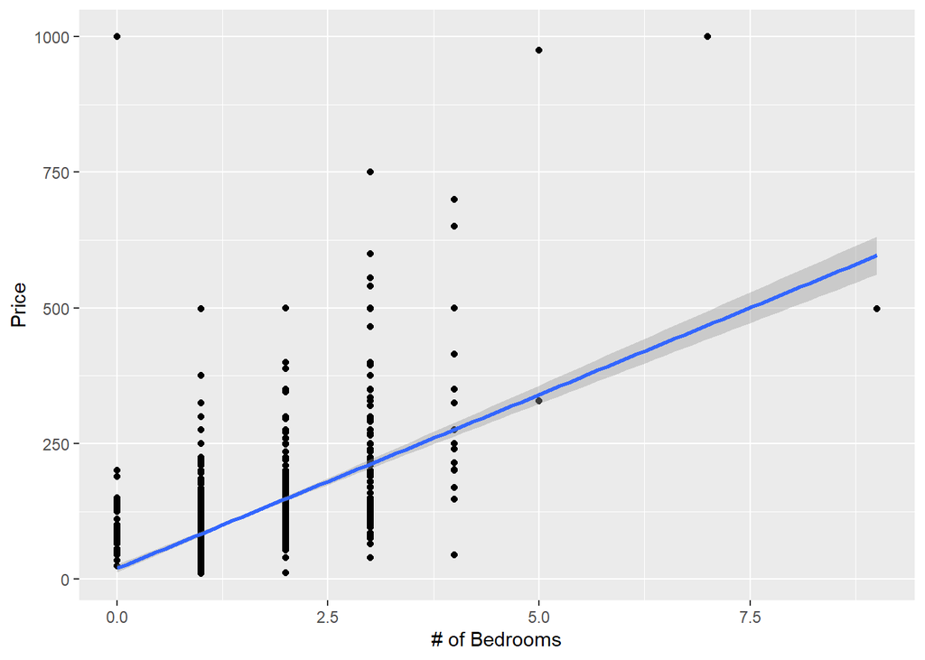

```r
ggplot(airbnb, aes(bedrooms, price)) +
geom_point() +
geom_smooth(method = lm) +
labs(x="# of Bedrooms", y="Price")
```

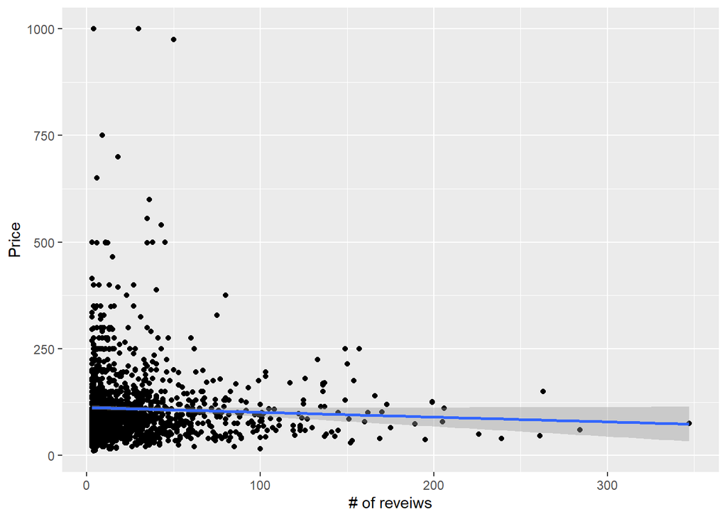

```r
ggplot(airbnb, aes(reviews, price)) +
geom_point() +
geom_smooth(method = lm) +
labs(x="# of reveiws", y="Price")
```

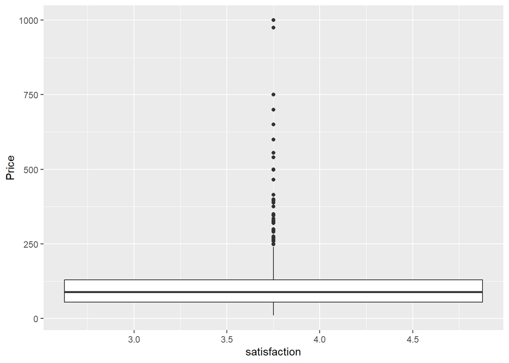

```r
ggplot(airbnb, aes(overall_satisfaction, price)) +
geom_boxplot() +
labs(x="satisfaction", y="Price")
```

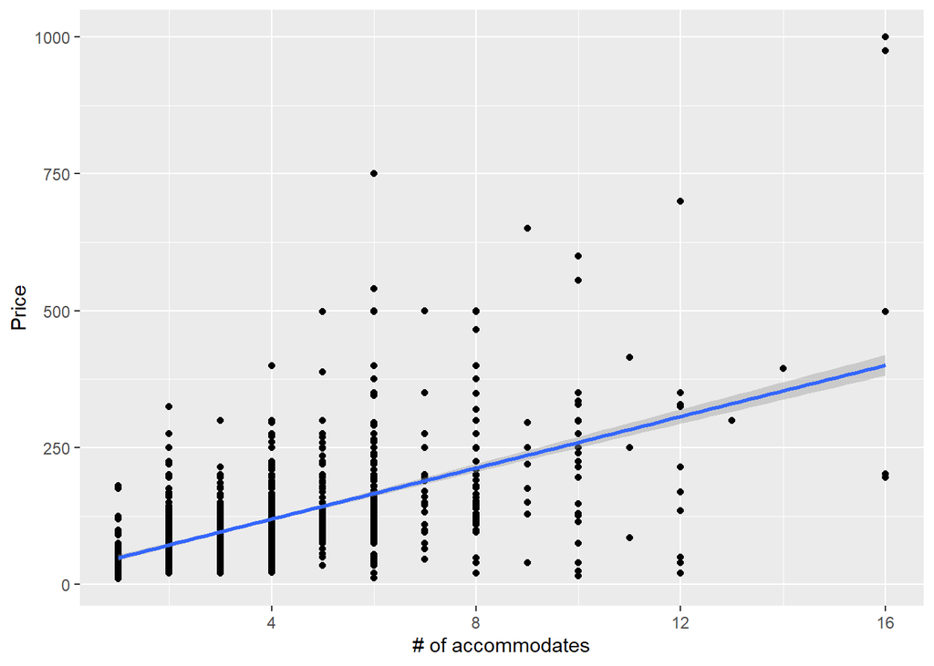

```r
ggplot(airbnb, aes(accommodates, price)) +
geom_point() +
geom_smooth(method = lm) +
labs(x="# of accommodates", y="Price")
```

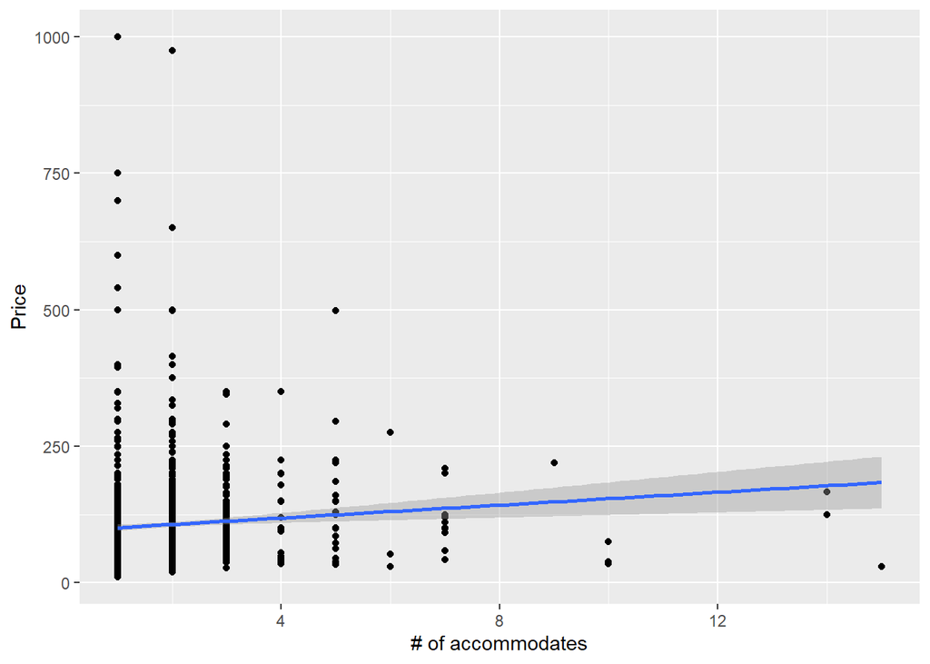

```r
ggplot(airbnb, aes(minstay, price)) +
geom_point() +
geom_smooth(method = lm) +
labs(x="# of accommodates", y="Price")
```

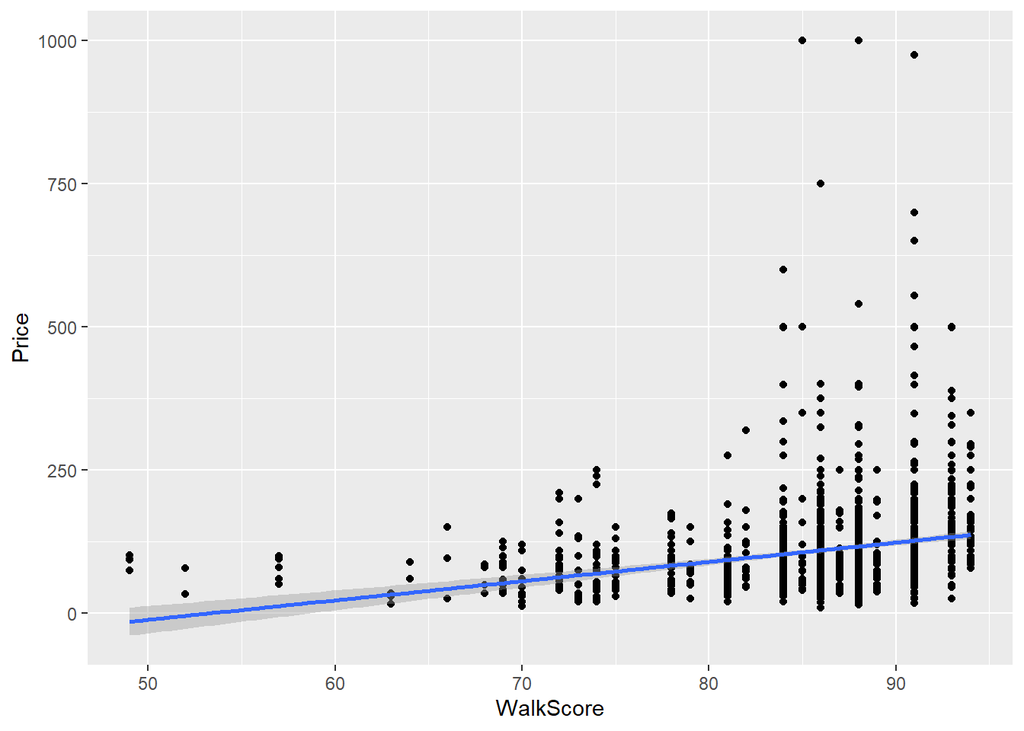

```r
ggplot(airbnb, aes(WalkScore, price)) +
geom_point() +
geom_smooth(method = lm) +
labs(x="WalkScore", y="Price")
```

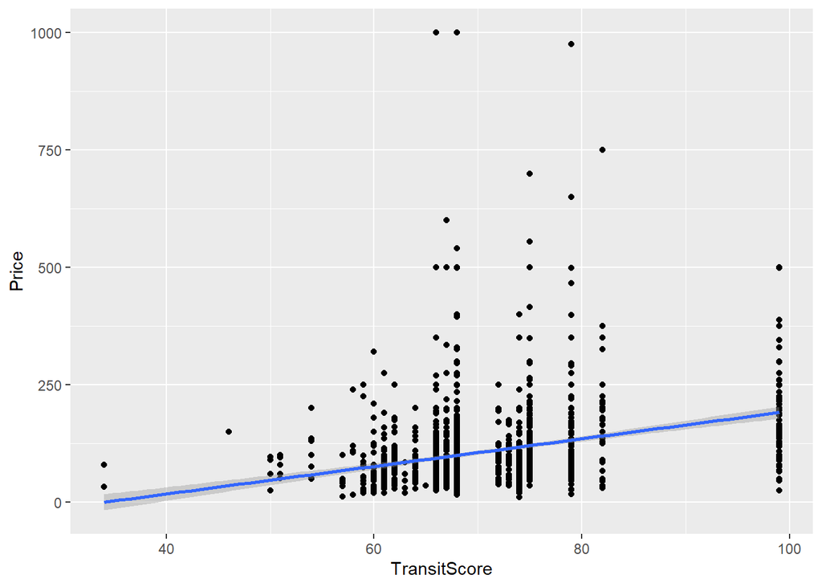

```r
ggplot(airbnb, aes(TransitScore, price)) +
geom_point() +
geom_smooth(method = lm) +
labs(x="TransitScore", y="Price")
```

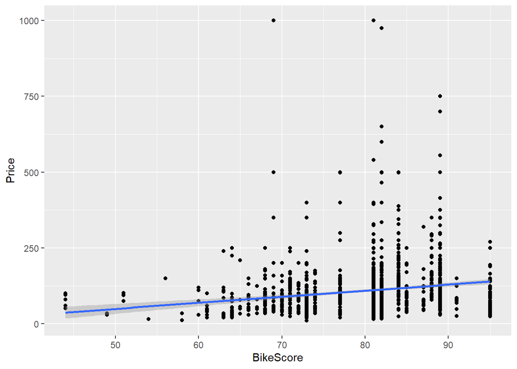

```r
ggplot(airbnb, aes(BikeScore, price)) +
geom_point() +
geom_smooth(method = lm) +
labs(x="BikeScore", y="Price")
```

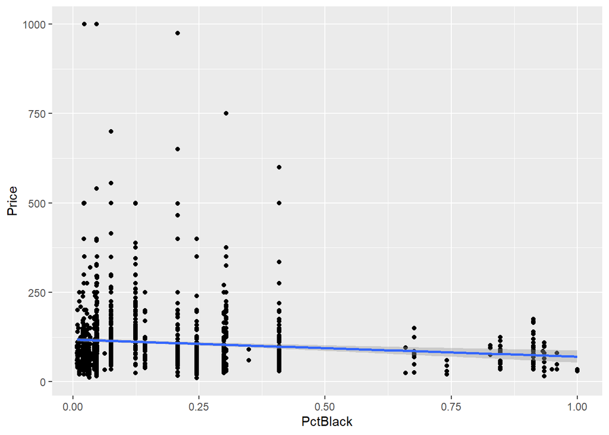

```r
ggplot(airbnb, aes(PctBlack, price)) +
geom_point() +
geom_smooth(method = lm) +
labs(x="PctBlack", y="Price")
```

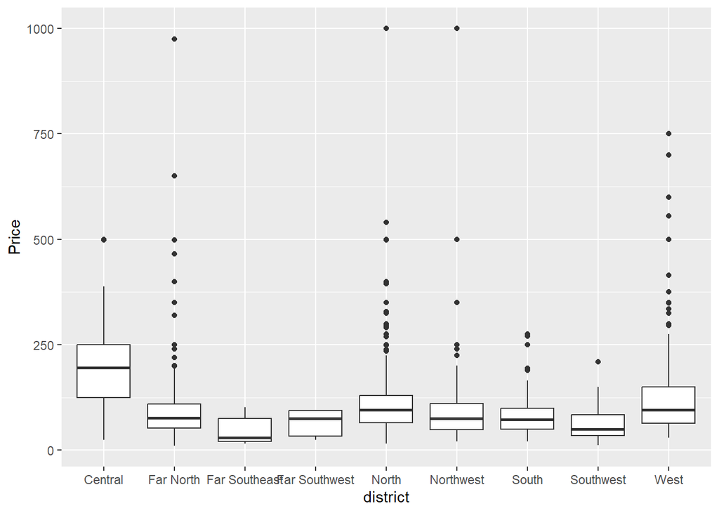

```r
ggplot(airbnb, aes(district, price)) +
geom_boxplot() +
labs(x="district", y="Price")
```

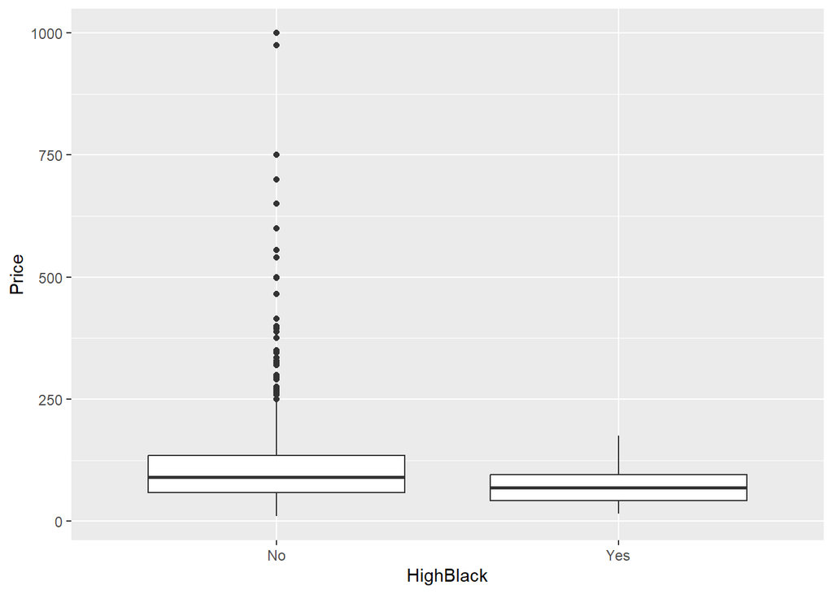

```r
ggplot(airbnb, aes(HighBlack, price)) +
geom_boxplot() +
labs(x="HighBlack", y="Price")
```

```r
numeric_columns <- airbnb[sapply(airbnb, is.numeric)]
cor(numeric_columns)
```

```
##                              ...1       price overall_satisfaction      reviews
## ...1                  1.000000000  0.15737261          0.031513332  0.011394829
## price                 0.157372612  1.00000000          0.075555568 -0.044269320
## overall_satisfaction  0.031513332  0.07555557          1.000000000  0.062306603
## reviews               0.011394829 -0.04426932          0.062306603  1.000000000
## accommodates          0.022987193  0.61443594         -0.112138241  0.018548097
## bedrooms              0.001771884  0.56907940         -0.051925462 -0.008109675
## minstay                        NA          NA                   NA           NA
## WalkScore             0.233064634  0.24733893          0.086731877 -0.013535466
## TransitScore          0.513663706  0.31174080         -0.005780318  0.004401275
## BikeScore             0.109977484  0.18525472          0.024517300 -0.016199379
## PctBlack             -0.029712215 -0.11786296         -0.141224509  0.029681919
##                      accommodates     bedrooms minstay   WalkScore TransitScore
## ...1                   0.02298719  0.001771884      NA  0.23306463  0.513663706
## price                  0.61443594  0.569079404      NA  0.24733893  0.311740796
## overall_satisfaction  -0.11213824 -0.051925462      NA  0.08673188 -0.005780318
## reviews                0.01854810 -0.008109675      NA -0.01353547  0.004401275
## accommodates           1.00000000  0.737447911      NA  0.06188365  0.085088877
## bedrooms               0.73744791  1.000000000      NA  0.01772223 -0.027927162
## minstay                        NA           NA       1          NA           NA
## WalkScore              0.06188365  0.017722233      NA  1.00000000  0.583239744
## TransitScore           0.08508888 -0.027927162      NA  0.58323974  1.000000000
## BikeScore              0.03240082  0.018909111      NA  0.66225379  0.383648184
## PctBlack              -0.03687533 -0.062672600      NA -0.45875778  0.027056143
##                        BikeScore    PctBlack
## ...1                  0.10997748 -0.02971222
## price                 0.18525472 -0.11786296
## overall_satisfaction  0.02451730 -0.14122451
## reviews              -0.01619938  0.02968192
## accommodates          0.03240082 -0.03687533
## bedrooms              0.01890911 -0.06267260
## minstay                       NA          NA
## WalkScore             0.66225379 -0.45875778
## TransitScore          0.38364818  0.02705614
## BikeScore             1.00000000 -0.12521776
## PctBlack             -0.12521776  1.00000000
```

```r
airbnb_model_test <- lmer(price ~ .^2 + (1|neighborhood),
REML=T, data=airbnb)
```

```
## fixed-effect model matrix is rank deficient so dropping 841 columns / coefficients
```

```r
summary(airbnb_model_test)
```

[output not shown]

[output cut: 536 more lines]

[output not shown]

```
##
## Correlation matrix not shown by default, as p = 286 > 12.
## Use print(x, correlation=TRUE)  or
##     vcov(x)        if you need it
```

```
## fit warnings:
## fixed-effect model matrix is rank deficient so dropping 841 columns / coefficients
## Some predictor variables are on very different scales: consider rescaling
```

```r
airbnb.model1 <- lmer(price ~ HighBlack + TransitScore + bedrooms +
reviews +
overall_satisfaction + room_type + (1|neighborhood),
REML=T, data=airbnb)
summary(airbnb.model1)
```

```
## Linear mixed model fit by REML ['lmerMod']
## Formula:
## price ~ HighBlack + TransitScore + bedrooms + reviews + overall_satisfaction +
##     room_type + (1 | neighborhood)
##    Data: airbnb
##
## REML criterion at convergence: 17323.9
##
## Scaled residuals:
##     Min      1Q  Median      3Q     Max
## -3.9891 -0.4185 -0.0636  0.2807 14.8197
##
## Random effects:
##  Groups       Name        Variance Std.Dev.
##  neighborhood (Intercept)  111.9   10.58
##  Residual                 3889.6   62.37
## Number of obs: 1561, groups:  neighborhood, 43
##
## Fixed effects:
##                         Estimate Std. Error t value
## (Intercept)           -245.00684   30.90729  -7.927
## HighBlackYes           -14.43517    8.10762  -1.780
## TransitScore             2.40153    0.28251   8.501
## bedrooms                52.33934    2.33037  22.460
## reviews                 -0.10234    0.04563  -2.243
## overall_satisfaction    28.60932    4.78402   5.980
## room_typePrivate room  -40.47168    3.79052 -10.677
## room_typeShared room   -61.07615    9.56368  -6.386
##
## Correlation of Fixed Effects:
##             (Intr) HghBlY TrnstS bedrms reviws ovrll_ rm_tPr
## HighBlackYs -0.151
## TransitScor -0.652  0.060
## bedrooms    -0.209  0.023  0.079
## reviews      0.015 -0.041 -0.009 -0.008
## ovrll_stsfc -0.736  0.107 -0.003  0.034 -0.062
## rm_typPrvtr -0.140 -0.047  0.118  0.481 -0.027 -0.056
## rm_typShrdr -0.111 -0.050  0.090  0.197  0.047  0.009  0.246
```

```r
airbnb.model2 <- lmer(price ~ HighBlack + TransitScore +
reviews +
overall_satisfaction + room_type + (1|neighborhood),
REML=T, data=airbnb)
summary(airbnb.model2)
```

```
## Linear mixed model fit by REML ['lmerMod']
## Formula: price ~ HighBlack + TransitScore + reviews + overall_satisfaction +
##     room_type + (1 | neighborhood)
##    Data: airbnb
##
## REML criterion at convergence: 17764.4
##
## Scaled residuals:
##     Min      1Q  Median      3Q     Max
## -2.6636 -0.4421 -0.1068  0.1928 11.9190
##
## Random effects:
##  Groups       Name        Variance Std.Dev.
##  neighborhood (Intercept)  121     11.00
##  Residual                 5158     71.82
## Number of obs: 1561, groups:  neighborhood, 43
##
## Fixed effects:
##                         Estimate Std. Error t value
## (Intercept)           -101.35342   34.06754  -2.975
## HighBlackYes           -18.51584    9.04378  -2.047
## TransitScore             1.91998    0.30779   6.238
## reviews                 -0.09540    0.05252  -1.816
## overall_satisfaction    24.97826    5.49976   4.542
## room_typePrivate room  -81.43533    3.82398 -21.296
## room_typeShared room  -103.37327   10.76726  -9.601
##
## Correlation of Fixed Effects:
##             (Intr) HghBlY TrnstS reviws ovrll_ rm_tPr
## HighBlackYs -0.151
## TransitScor -0.635  0.060
## reviews      0.015 -0.043 -0.009
## ovrll_stsfc -0.761  0.109 -0.006 -0.062
## rm_typPrvtr -0.049 -0.067  0.099 -0.027 -0.082
## rm_typShrdr -0.074 -0.056  0.079  0.049  0.003  0.176
```